# Circular Motion

In this lecture we introduce uniform circular motion with an emphasis on the concept of centripetal force.

### Frequency and Period

Frequency (revolutions per second) $f$ [ $s^{-1}$ or $\mathrm{Hz}$]

Period (time for one revolution) $T=\frac{1}{f}$ [$\mathrm{s}$]

Velocity $v=\frac{2\pi r}{T}=2\pi r f$ [$ms^{-1}$]

### Newton's First Law

**Every object continues in its state of rest, or of uniform velocity in a straight line, as long as no net force acts on it.**

From Newton's first law we can see that circular motion can only occur when a net force acts on an object.

### Releasing a ball from a circular path

Unlike in baseball, cricketers may not extend their elbows during the bowling action. (Clearly, flexing the elbow, or “chucking” is “just not cricket”).

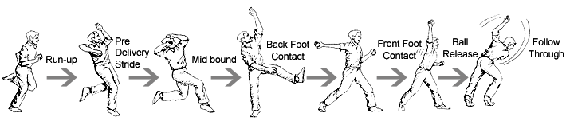

Neglecting effects such as spin, you can see that the path of the ball after release is essentially tangential to it's velocity.

### Acceleration in circular motion

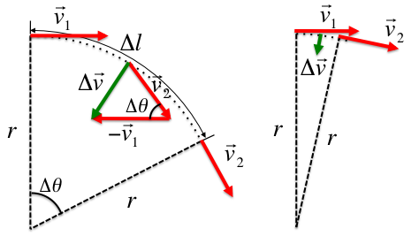

The magnitude of the velocity does not change, but it's direction does. The vector for the change of the velocity always points towards the center of the circle. There is thus an acceleration, named the **centripetal acceleration** pointing to the center of the circle. For small changes in the position.

$\Delta v=2v\sin(\frac{\Delta\theta}{2})\approx v \Delta\theta$

$\Delta\theta=\frac{\Delta l}{r}$

$v\Delta\theta=v\frac{\Delta l}{r}$

$a_{R}=\lim_{\Delta t\to 0}\frac{\Delta v}{\Delta t} = \lim_{\Delta t\to 0} \frac{v}{r}\frac{\Delta l}{\Delta t}=\frac{v^2}{r}$

$\Delta v=2v\sin(\frac{\Delta\theta}{2})\approx v \Delta\theta$

$\Delta\theta=\frac{\Delta l}{r}$

$v\Delta\theta=v\frac{\Delta l}{r}$

$a_{R}=\lim_{\Delta t\to 0}\frac{\Delta v}{\Delta t} = \lim_{\Delta t\to 0} \frac{v}{r}\frac{\Delta l}{\Delta t}=\frac{v^2}{r}$

### Centripetal Force

Newton's second law tells us we can only have a centripetal acceleration towards the center of a circular motion path if the sum of the forces in the radial direction

$\sum F_R=ma_R=m\frac{v^2}{R}$

This **centripetal** force must be provided in some way for circular motion to occur.

Do not be misled in to thinking that such a thing as **centrifugal** force exists. As we saw earlier if the centripetal force is removed an object continues in a tangential, not perpendicular path to the motion. Of course in situations where you are in circular motion, it can feel as if you are being pushed out from the center, but this is in fact **you** applying the equal and opposite reaction force required by Newton's 3rd Law. The force on **you** is directed inwards.

### Centrifuges

NASA uses this centrifuge to subject people to centripetal accelerations of up to 20G!

[figure not shown]

If a person sits 10m from the center of the centrifuge, how fast does the centrifuge have to turn for a person to be subjected to force of 20G?

### Centrifuge Solution

$\Sigma F = m_{p} 20g $

$\frac{mv^{2}}{r}=m20g$

$v^{2}=200g$

$v=44.3 \mathrm{ms^{-1}}$

### Circular motion on a spring

Springs extend or contract as a force is exerted on them. The force on a spring can be considered to be directly proportional to it's extension. If a spring is used to provide the centripetal force on an object, the equal and opposite reaction force on it will stretch it out.

By swinging a weight on a spring in horizontal circle above my head I can demonstrate that the force required depends on the velocity.

### Vertical circle

If we now try to move the mass on spring in a vertical circle we can see it doesn't happen. The force required is different at the top and bottom because gravity alternatively assists or hinders us at the top and bottom of the path and as the spring changes it's length according to the tension on it the resulting motion is not circular.

A ball on a string works, providing the velocity is greater than $v=\sqrt{rg}$

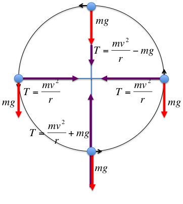

### Looping plane

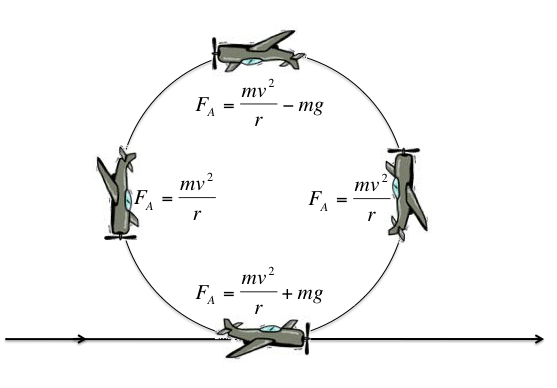

A plane in a circular loop is a similar problem. Here we can also consider the force F A that the plane needs to apply as it goes through the loop. [Things not attached to the plane](https://www.youtube.com/watch?v=mVp0Bv39NRM) will still be subject to gravity.

### Conical Pendulum

See 5.6 of this [physclips video](http://www.animations.physics.unsw.edu.au/mechanics/chapter5_Newton.html) for a nice example.

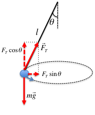

How fast does it go?

$F_{T}\cos\theta=mg$

$F_{T}\sin\theta=\frac{mv^{2}}{r}$

$v^2=\frac{rF_{T}\sin\theta}{m}$ $v=\sqrt{\frac{r}{m}(\frac{mg}{\cos\theta})\sin\theta}=\sqrt{\frac{rg\sin\theta}{\cos\theta}}$

Rather than $r$ we would like an expression in $l$ so we sub in $r=l\sin\theta$

$v=\sqrt{\frac{lg\sin^{2}\theta}{\cos\theta}}$

To get the period of rotation, divide the path length $2\pi r$ = $2\pi l\sin\theta$ by $v$

$T=2\pi l \sin\theta \sqrt{\frac{\cos\theta}{lg\sin^{2}\theta}}=2\pi\sqrt{\frac{l\cos\theta}{g}} $

Rather than $r$ we would like an expression in $l$ so we sub in $r=l\sin\theta$

$v=\sqrt{\frac{lg\sin^{2}\theta}{\cos\theta}}$

To get the period of rotation, divide the path length $2\pi r$ = $2\pi l\sin\theta$ by $v$

$T=2\pi l \sin\theta \sqrt{\frac{\cos\theta}{lg\sin^{2}\theta}}=2\pi\sqrt{\frac{l\cos\theta}{g}} $

### Cars and turns

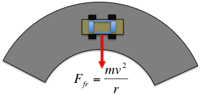

When a car rounds a bend the question of whether it slips or not is a **static** friction problem. We consider the car not to be moving in the direction perpendicular to it's motion. It will remain stationary in this direction if the maximum possible static friction force

$\mu_{s}N=\frac{mv^{2}}{r}$

or

$v^{2} \lt \mu_{s} g r$

As you can see, on wet or icy roads you should slow down round bends!

### Banked turns

Roads designed for high speed traffic will often used banked turns to increase the maximum speed for which slipping does not occur. A well designed banked turn means the car should not rely on friction. (It also makes the problem easier.)

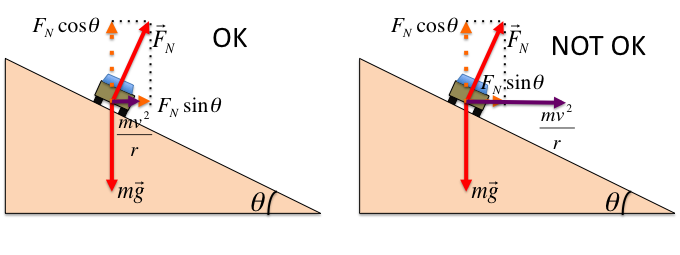

The relationship between maximum speed, radius and the bank angle can be found from considering the forces

$F_{N}\cos\theta=mg$

$mg\frac{\sin{\theta}}{\cos{\theta}}=\frac{mv^{2}}{r}$

$\tan{\theta}=\frac{v^2}{rg}$

or with friction

$F_{N}\sin\theta+\mu F_{N}\cos\theta=\frac{mv^{2}}{r}$

$F_{N}\cos\theta-\mu F_{N}\sin\theta=mg$

$\frac{\sin\theta+\mu\cos\theta}{\cos\theta-\mu\sin\theta}=\frac{v^2}{rg}$

### Non Uniform circular motion

We have so far seen univorm circular motion, where the net force on the object is exerwtard the center of the circle in the motion plane. We can call also this the radial force.

If the net force is exerted at an angle and not towards the center, then we can decompose it in tangencial and radial parts. The component directed towars the center gives rise to the centripetal acceleration and keeps the object moving in a circle. the one tangent to the circle acts to increase or decrease the speed and thefroe gives rise to a component of the acceleration tangent to the circle.

In other words, when the speed of the bject changes, there must be a tangential component of the force.